# LOS modelling for Lions Gate Hospital

Nayef Ahmad - VCH Decision Support

July 11, 2018

## Summary

Preliminary data analysis shows that Length of stay (LOS) at Lions Gate Hospital may depend on the **day of the week of admission**. To test this hypothesis, we must isolate the effect of the day of week of admission by adjusting for other variables such as **patient age** and **admission nursing unit**. We must also determine whether observed differences can be attributed to chance alone, or whether they represent true underlying differences.

For this purpose, we developed a multivariate model to predict average LOS using patient age, admission unit and admission day of week. Using all 3 of these variables improves prediction by around 4.4% compared to the baseline model that uses only nursing unit to predict average LOS (using mean absolute error for comparison). Thus, even though the model was built primarily for inference, it may be useful for prediction as well. The mean absolute error of predictions from the model is 3.1 days.

We conclude that there is an effect on LOS due to day of week of admission. Using **Monday as a baseline**:

- patients admitted on **Thursdays** have a significantly higher LOS by 5.43% on average.
- On **Tuesdays, Wednesdays, and Saturdays**, average LOS is significantly lower by 10.75%, 8.57% and 15.07%.
- LOS on **Fridays and Sundays** is not significantly different from Mondays.

The multivariate regression model we developed has the general form:

$${log(avgLOS)_i} = \alpha + \beta_{1} nurse.unit_{i} + \beta_{2} age_{i} + \beta_{3} day.of.week_{i} + \epsilon_{i}$$
The coefficients for each level of the variables in the model are included in the appendix.

Examples of other questions that arise from the interaction of the effects of age, nursing unit and day of week include: Is the effect of age different for patients admitted to different units, after adjusting for day of week? Is the effect of weekends different in surgery units and medical units after adjusting for age? These questions are important because managers make decisions based on their intuitive understanding of these relationships. In LGH, a new position was recently created (“dishcarge chaser”) partly based on the belief that patients admitted around the weekend have longer LOS.

## Illustrative Examples

The tables below illustrate how the model adjusts the predicted average LOS based on patient age and admission day of week. In the first table, only the age is varied for patients admitted on Monday to 4E and 6E units. The first six rows show predictions for 4E, the next six show predictions for 6E.

In the second table, only day of week is varied for patients of age 40 years admitted to 4E and 6E.

#### Effect of age (adjusted for other variables):

| site | dow | age | unit.code | los.predicted |
| --- | --- | --- | --- | --- |
| Lions Gate Hospital | Monday | 20 | 4E | 5.973711 |
| Lions Gate Hospital | Monday | 30 | 4E | 6.904888 |
| Lions Gate Hospital | Monday | 40 | 4E | 7.988460 |
| Lions Gate Hospital | Monday | 50 | 4E | 9.246016 |
| Lions Gate Hospital | Monday | 60 | 4E | 10.703354 |
| Lions Gate Hospital | Monday | 70 | 4E | 12.391086 |
| Lions Gate Hospital | Monday | 20 | 6E | 3.319137 |
| Lions Gate Hospital | Monday | 30 | 6E | 3.777994 |
| Lions Gate Hospital | Monday | 40 | 6E | 4.324649 |
| Lions Gate Hospital | Monday | 50 | 6E | 4.971932 |
| Lions Gate Hospital | Monday | 60 | 6E | 5.733591 |
| Lions Gate Hospital | Monday | 70 | 6E | 6.624784 |

#### Effect of day of week (adjusted for other variables):

| site | dow | age | unit.code | los.predicted |
| --- | --- | --- | --- | --- |
| Lions Gate Hospital | Monday | 40 | 4E | 7.988460 |
| Lions Gate Hospital | Tuesday | 40 | 4E | 7.132819 |
| Lions Gate Hospital | Wednesday | 40 | 4E | 7.306312 |
| Lions Gate Hospital | Thursday | 40 | 4E | 8.421179 |
| Lions Gate Hospital | Friday | 40 | 4E | 7.935207 |
| Lions Gate Hospital | Saturday | 40 | 4E | 6.790065 |
| Lions Gate Hospital | Sunday | 40 | 4E | 7.683692 |
| Lions Gate Hospital | Monday | 40 | 6E | 4.324649 |
| Lions Gate Hospital | Tuesday | 40 | 6E | 3.891951 |
| Lions Gate Hospital | Wednesday | 40 | 6E | 3.979081 |
| Lions Gate Hospital | Thursday | 40 | 6E | 4.546047 |
| Lions Gate Hospital | Friday | 40 | 6E | 4.297513 |
| Lions Gate Hospital | Saturday | 40 | 6E | 3.720817 |
| Lions Gate Hospital | Sunday | 40 | 6E | 4.169698 |

## Methodology

LOS data is strictly positive and highly non-normal, which is why ordinary least squares regression is not appropriate. We used a zero-truncated Poisson regression model (for details, see [this example](https://stats.idre.ucla.edu/r/dae/zero-truncated-poisson/)). The model was trained on data from the full calendar year of 2017, and tested on data from January and February 2018.

Likelihood ratio tests were used to test for significant improvements in model performance as variables were added to the model. Model residuals were inspected visually and using quantile regression to assess the assumption that the response variable has a zero-truncated Poisson distribution.

The graphs below illustrate the model performance on the training and test data.

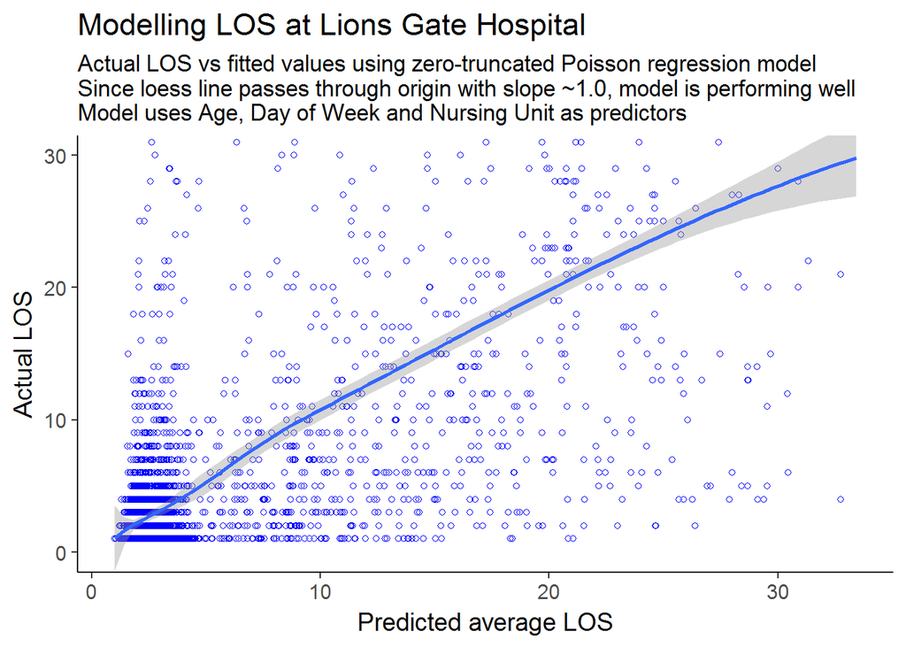

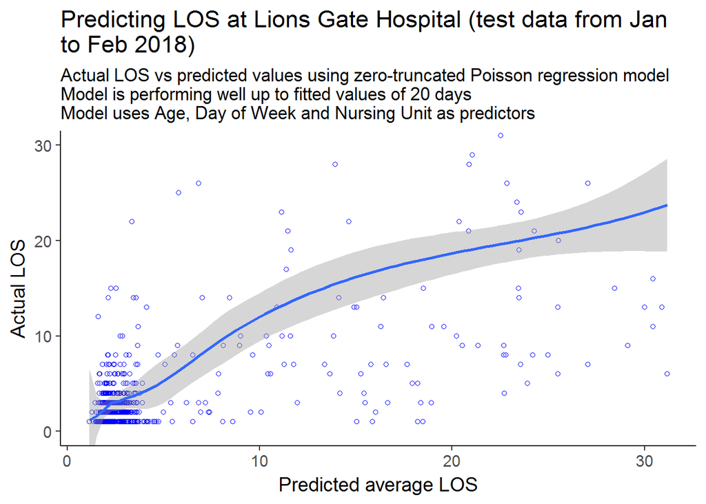

# Possible extensions to the model

It may be worth extending this model both as a tool for inference about the relationships between variables that affect LOS, and for the purpose of predicting LOS at Lions Gate Hospital. The following variables may be useful in improving the predictions of the model:

- Gender
- Admission Category Group
- Admission Patient Service (current encounter and previous encounters)
- Number of previous acute episodes in last year
- Number of previous ED visits in last year
- ED admit vs direct admit
- Chronic diseases

# Appendix: Zero-truncated Poisson Regression Model

```
##
## Call:
## vglm(formula = losdays ~ dow + age + unit.code, family = pospoisson(),
##     data = df1.raw.data)
##
##
## Pearson residuals:
##                 Min     1Q  Median     3Q   Max
## loge(lambda) -5.025 -1.084 -0.4875 0.3636 66.33
##
## Coefficients:
##                                      Estimate Std. Error z value Pr(>|z|)
## (Intercept)                         0.9529996  0.0840731  11.335  < 2e-16
## dowTuesday                         -0.1137544  0.0258102  -4.407 1.05e-05
## dowWednesday                       -0.0895939  0.0251287  -3.565 0.000363
## dowThursday                         0.0528716  0.0244277   2.164 0.030433
## dowFriday                          -0.0067072  0.0249092  -0.269 0.787726
## dowSaturday                        -0.1633314  0.0394573  -4.139 3.48e-05
## dowSunday                          -0.0390195  0.0366033  -1.066 0.286419
## age                                 0.0146439  0.0005564  26.319  < 2e-16
## unit.code3E                        -0.3103045  0.0937379  -3.310 0.000932
## unit.code3W                        -0.5797255  0.1525287  -3.801 0.000144
## unit.code4E                         0.5389040  0.0851936   6.326 2.52e-10
## unit.code4W                         0.5932134  0.0753543   7.872 3.48e-15
## unit.code5E                         1.0774854  0.0739714  14.566  < 2e-16
## unit.code6E                        -0.0885913  0.0837451  -1.058 0.290115
## unit.code6W                         0.2151108  0.0807048   2.665 0.007690
## unit.code7E                         1.0570433  0.0790719  13.368  < 2e-16
## unit.code7W                         0.1737497  0.0800304   2.171 0.029928
## unit.codeCarlile Youth CD Ctr - IP  1.9345319  0.0828873  23.339  < 2e-16
## unit.codeECC                       -0.4484701  0.5269421  -0.851 0.394725
## unit.codeICU                        0.5465786  0.0795467   6.871 6.37e-12
## unit.codeIPS                       -0.8882020  0.0730262 -12.163  < 2e-16
## unit.codeLD                        -0.6631873  0.0773502  -8.574  < 2e-16
## unit.codeMIU                        1.2766939  0.0764755  16.694  < 2e-16
## unit.codeNCU                        0.7252013  0.0936617   7.743 9.73e-15
## unit.codeOR                         0.4392114  0.1613633   2.722 0.006491
## unit.codePAR                       -0.8473448  0.0850810  -9.959  < 2e-16
## unit.codeSCO                        0.8203850  0.1185220   6.922 4.46e-12
##
```

[output cut: 24 more lines]

```
## unit.codeOR                        **
## unit.codePAR                       ***
## unit.codeSCO                       ***
## ---
## Signif. codes:  0 '***' 0.001 '**' 0.01 '*' 0.05 '.' 0.1 ' ' 1
##
## Number of linear predictors:  1
##
## Name of linear predictor: loge(lambda)
##
## Log-likelihood: -15035.2 on 4859 degrees of freedom
##
## Number of iterations: 7
##
## No Hauck-Donner effect found in any of the estimates
```

### Comparison with null model

| model | rmse | mae |
| --- | --- | --- |
| los ~ unit (OLS) | 7.567942 | 3.271747 |
| los ~ unit + age + dow (0-trunc. Pois) | 7.547195 | 3.126200 |